# Reproducible Research: Peer Assessment 1

## Loading and preprocessing the data

To load the data, I am using read.csv function. Then data cleanup is performed:

```r
# read data
data <- read.csv("activity.csv")
# clean
data$date <- as.Date(data$date)
data$interval <- as.numeric(data$interval)
data$steps <- as.numeric(data$steps)
```

Now, I aggregte number of steps taken over dates and generate a histogram:

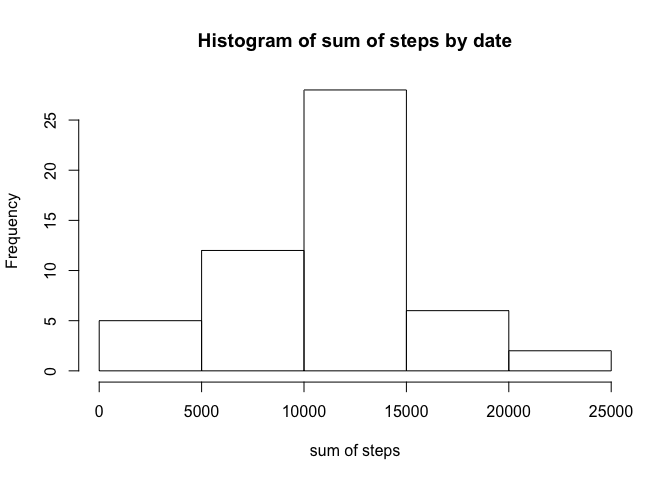

```r
sumByDate <- aggregate(steps ~ date, data, sum)
hist(sumByDate$steps, main="Histogram of sum of steps by date", xlab="sum of steps")
```

## What is mean total number of steps taken per day?

To calculate the mean and median, following code is used:

```r
meanOfStepsTakenPerDay <- mean(sumByDate$steps)
medianOfStepsTakenPerDay <- median(sumByDate$steps)
```

[output not shown]

## What is the average daily activity pattern?

Here is a plot for the Average Daily Activity Pattern:

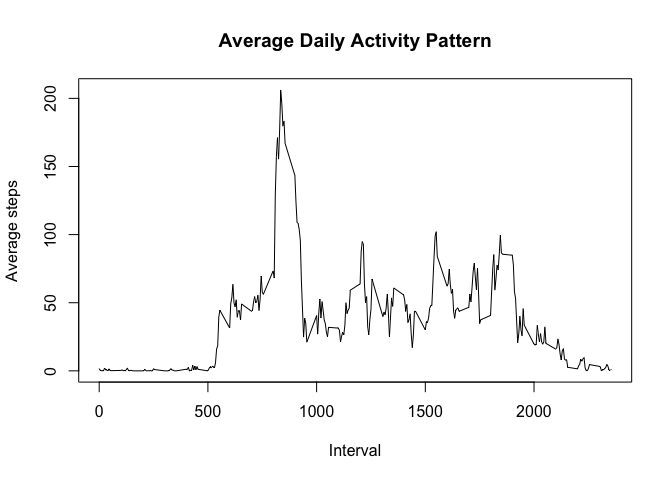

```r
avgByInterval <- aggregate(steps ~ interval, data, mean)
plot(avgByInterval$interval, avgByInterval$steps, type="l", main="Average Daily Activity Pattern", xlab="Interval", ylab="Average steps")
```

To compute the interval where maximum activity takes place, following is used:

```r
maxIndex <- which.max(avgByInterval$steps)
maxInterval <- avgByInterval[maxIndex, 1]
```

So the 5-minute interval, on average across all the days in the dataset, that contains the maximum number of steps is **835**

## Imputing missing values

The data set has **2304** missing values for steps.

The strategy used here for filling in all of the missing values in the dataset is to use the `impute` package and then uses its knn function to populate missing values:

```r
library(impute)
data2 <- data
dataMatrix <- data.matrix(data2)
dataMatrix <- impute.knn(dataMatrix)$data
data2$steps <- dataMatrix[,1]
sumByDate2 <- aggregate(steps ~ date, data2, sum)
```

The histogram of new data is:

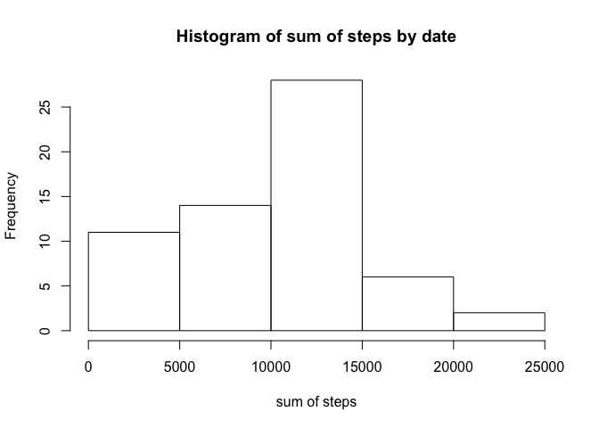

```r
hist(sumByDate2$steps, main="Histogram of sum of steps by date", xlab="sum of steps")
```

Calculating mean and median of new data:

```r
mean2OfStepsTakenPerDay <- mean(sumByDate2$steps)
median2OfStepsTakenPerDay <- median(sumByDate2$steps)
```

## Are there differences in activity patterns between weekdays and weekends?

I am writing a helper function to get label (weekday/weekend) for the specified date:

```r
getLabelForDate <- function (date){
  day <- weekdays(date)
  if (day == "Saturday" || day == "Sunday") {
    label <- "weekend"
  } else {
    label <- "weekday"
  }
  label
}
```

Now, to add a new factor variable in the dataset with two levels, I simply call the helper function for each row:

```r
data$dayLabel <- sapply(data$date, function(d) getLabelForDate(d))
```

Now, we get the average:

```r
averageStepsOverDayLabel <- aggregate(steps ~ interval + dayLabel, data, mean)
```

Finally, the plot looks like this:

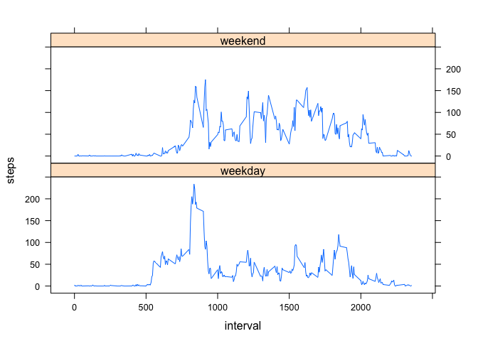

```r
library(lattice)
with(averageStepsOverDayLabel, xyplot(steps ~ interval | dayLabel, layout=c(1,2), type="l"))
```